# Gaussian processes

## Gaussian processes

Gaussian processes are distributions over *functions* and can be used for both classification and regresssion. In this section, we explore Gaussian processes in regression.

**Exercise 1**. Use the provided function below to generate 50 noisy data points with $\sigma=0.1$ (standard deviation of the Gaussian noise added). Plot the resulting data points.

```python
def synth_data(n_samples, sigma):
    X = np.random.uniform(low=0,high=2,size=n_samples)
    X = np.sort(X)
    y = np.sin(4*X) + np.random.normal(loc=0,scale=sigma,size=n_samples)
    return X, y
```

We will use a radial basis function (RBF) as kernel for constructing the covariance matrix. The RBF kernel is given by:

$$k(x_1,x_2) = exp\left( \frac{-1}{2}||x_1 - x_2||^2/l^2 \right)$$

Using this kernel, we build a covariance matrix.

```python
def kernel_rbf(x1, x2, l):
    Sigma = [[np.exp(-0.5*abs((x1[i]-x2[j])/l)**2) for j in range(len(x2))] for i in range(len(x1))]
    Sigma = np.array(Sigma)
    return Sigma
```

**Exercise 2**. Create a numeric array of length 200 spanning from -0.5 to 2.5. This array will represent our test objects $x_*$ over which we will do predictions. Without any training set, we will first randomly generate sample functions from a Gaussian process. Set up the covariance matrix `Sigma` by calling the provided function **kernel_rbf()** over the test objects $x_∗$.

```python
X_test = np.linspace(-0.5,2.5,200)
Sigma = kernel_rbf(X_test, X_test, l=1)
```

Then use **np.random.multivariate_normal()** to generate three samples from a multivariate Gaussian distribution with zero mean and covariance matrix given by `Sigma` which is a 200 $\times$ 200 matrix in this case. Each of these three samples is a function drawn from a Gaussian process. Store these three functions or numeric arrays as columns in a 2D-array by transposing the output of **np.random.multivariate_normal()**. Plot the sample functions:

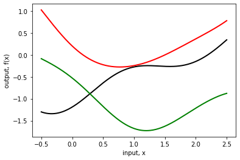

```python
colors = ['k','r','g','b','c','m','y','gray']*np.ceil(n_samples/8).astype(int)
for i in range(n_samples):
    plt.plot(X_test, values[:,i], c=colors[i], lw=2)

plt.xlabel('input, x')
plt.ylabel('output, f(x)')
plt.show()
```

**Exercise 3**. So far we have only sampled from the prior distribution. Let us now consider the artificially generated dataset in Exercise 1. The hyperparameters for setting up a Gaussian process in our case are the characteristic length-scale of the RBF kernel, $l$, and the standard deviation of Gaussian noise, $\sigma_{n}$ which we can tolerate around the training objects. Let us specify these hyperparameters arbitrarily for now with $\sigma_{n} = 0.5$ and $l=0.1$.

Recall that the test outputs, $f_{*}$, are given by:

$$\textbf{f}_{*} \sim \mathcal{N}\left( K(X_{*},X) [K(X,X) + \sigma_n^2 \textbf{I}]^{-1} \textbf{y}, K(X_{*},X_{*})-K(X_{*},X)[K(X,X)+\sigma_n^2 \textbf{I}]^{-1}K(X,X_{*})\right) $$

Start by computing the kernels:

```python
l, sigma_noise = 0.1, 0.5

k_xx = kernel_rbf(X_train, X_train, l)
k_xxs = kernel_rbf(X_train, X_test, l)
k_xsx = kernel_rbf(X_test, X_train, l)
k_xsxs = kernel_rbf(X_test, X_test, l)
```

Now, compute the mean of the posterior normal distribution: $K(X_{*},X) [K(X,X) + \sigma_n^2 \textbf{I}]^{-1} \textbf{y}$, where $\textbf{y}$ are the training outputs.

Also compute the covariance matrix of the posterior distribution: $K(X_{*},X_{*})-K(X_{*},X)[K(X,X)+\sigma_n^2 \textbf{I}]^{-1}K(X,X_{*})$

```python
fs = k_xsx.dot(np.linalg.inv(k_xx + sigma_noise**2 * np.identity(k_xx.shape[0]))).dot(y_train)
cov_fs = k_xsxs - k_xsx.dot(np.linalg.inv(k_xx + sigma_noise**2 * np.identity(k_xx.shape[0]))).dot(k_xxs)
```

Plot the mean function `fs` along with the original data points.

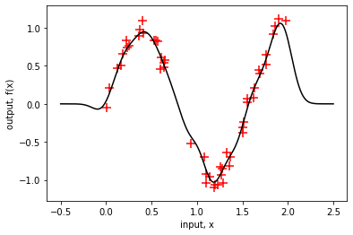

Finally, generate a few sample functions drawn from the posterior distribution i.e. using **np.random.multivariate_normal(fs,cov_fs,n_samples)** and plot these along with the original data points.

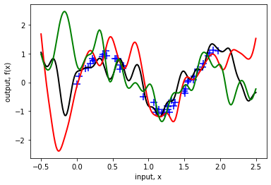

In Exercise 3, we trained a Gaussian process over the entire available dataset and we also selected the hyperparameters arbitrarily. In the next exercise, we will divide the dataset into a training set, validation set, and test set. The hyperparameters will be optimized over the validation set and the final performance will be measured over the test set.

**Exercise 4**. Starting from the artificially generated dataset, split the dataset into 60% training set, 20% validation set, and 20% test set (hint: you may use **train_test_split()** twice; module **sklearn.model_selection**). Plot the three datasets together and assign a proper legend.

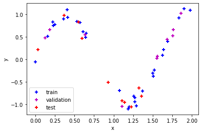

We are now ready to optimize the hyperparmeters using the training set and validation set. Select a range of values for $\sigma_n$ in $[0.3,1]$ and for $l$ in $[0.05,1]$. Iterate over each possible combination of $\sigma_n$ and $l$ and compute all kernels and the resulting mean function `fs` of the posterior distribution. Be careful how the kernels are computed. Also compute the mean square error (mse) between `fs` and `yval`, in addition to the median absolute error (mae). Use a 2D array to store the mse values and another one to store the mae values.

Use the mean square error measure in particular to select the optimal hyperparameters (hint: **argmin()** **np.unravel_index()**). What are the optimal values found for the hyperparameters? Display the error values as measured over the validation set (note: show the root mean square error (rmse), instead of mse)

```
                     rmse       mae
validation_error  0.11221  0.093208
```

Now that we have selected our hyperparameters, we evaluate the final performance over the test set. In this case, we can train over both the training set and validation set combined together (hint: **np.r_** or **np.hstack()**, etc.). Compute the kernels and posterior distribution mean and covariance matrix. Finally report the error measures over the test set.

```
                rmse       mae
test_error  0.101812  0.046427
```

**Exercise 5**. Train the final model using the optimized hyperparameters over the *entire dataset* and visualize the mean function along with 95\% confidence intervals. To compute these latter, we use the diagonal (i.e. variances) of the convariance matrix `cov_fs` to find the standard deviations and then set multiply by 1.96 (since for a normal distribution 95\% of the samples fall within $\pm 1.96 \sigma$).

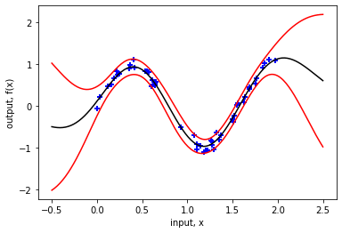

Plot a few sample functions drawn from the posterior distribution along with the original data points.

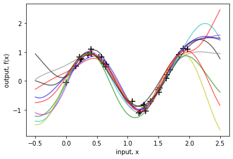

**Exercise 6**. Sklearn provides an implementation of Gaussian processes for regression. Study the code below and plot the model predictions along with 95% confidence intervals (i.e. $\pm 1.96$ `sd`). Also plot a few sample functions drawn from the posterior distribution.

```python
#GP using sklearn
from sklearn.gaussian_process import GaussianProcessRegressor
from sklearn.gaussian_process.kernels import RBF

kernel = RBF() #using default length_scale_bounds
model = GaussianProcessRegressor(kernel=kernel, alpha=0.5).fit(X.reshape(-1,1), y)
y_pred_posterior = model.sample_y(X_test.reshape(-1,1), n_samples=n_samples) #sample from posterior
y_pred, sd = model.predict(X_test.reshape(-1,1), return_std=True)

# ...
```

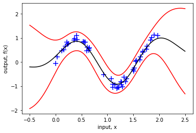

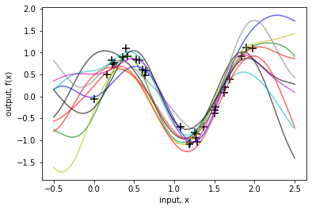